# Budowa modelu XGBoost na danych bankowych

## 4. Budowa modelu XGBoost

### 4.1 Model bazowy na domyślnych hiperparametrach

```python
from sklearn.preprocessing import StandardScaler

# Identyfikacja kolumn numerycznych i kategorycznych
numeric_cols_le = [c for c in X_train.columns if c not in categorical_cols]
categorical_cols_le = [c for c in X_train.columns if c in categorical_cols]

# Konwersja kolumn kategorycznych do typu pandas 'category' dla natywnego wsparcia XGBoost
X_train_cat = X_train.copy()
X_test_cat = X_test.copy()
X_valid_cat = X_valid.copy()

for col in categorical_cols_le:
    X_train_cat[col] = X_train_cat[col].astype('category')
    X_test_cat[col] = X_test_cat[col].astype('category')
    X_valid_cat[col] = X_valid_cat[col].astype('category')

# Normalizacja kolumn numerycznych
preprocessor_numeric = StandardScaler()
X_train_numeric = preprocessor_numeric.fit_transform(X_train[numeric_cols_le])
X_test_numeric = preprocessor_numeric.transform(X_test[numeric_cols_le])
X_valid_numeric = preprocessor_numeric.transform(X_valid[numeric_cols_le])

# Złączenie danych numerycznych i kategorycznych
X_train_le = pd.concat([
    pd.DataFrame(X_train_numeric, index=X_train.index, columns=numeric_cols_le),
    X_train_cat[categorical_cols_le]
], axis=1)

X_test_le = pd.concat([
    pd.DataFrame(X_test_numeric, index=X_test.index, columns=numeric_cols_le),
    X_test_cat[categorical_cols_le]
], axis=1)

X_valid_le = pd.concat([
    pd.DataFrame(X_valid_numeric, index=X_valid.index, columns=numeric_cols_le),
    X_valid_cat[categorical_cols_le]
], axis=1)
```

```python
# Obliczenie wagi dla klasy mniejszościowej w celu jawnego obsługi nierównomiernego rozkładu klas
# Zmienna docelowa 'y' reprezentuje decyzję klientów o subskrypcji lokaty terminowej
# Nierównomierna reprezentacja klas (więcej klientów nie subskrybujących niż subskrybujących)
# jest typowa w problemach marketingowych i wymaga specjalnego traktowania
pos_weight = (y_train == 0).sum() / (y_train == 1).sum()

# Inicjalizacja modelu XGBoost z obsługą natywnych zmiennych kategorycznych
# enable_categorical=True - bezpośrednie przetwarzanie kolumn typu 'category' bez kodowania
# tree_method='hist' - algorytm histogramowy, optymalny dla zmiennych kategorycznych
# scale_pos_weight - jawna obsługa nierównomierności klas
model1 = xgb.XGBClassifier(
    enable_categorical=True,
    tree_method='hist',
    scale_pos_weight=pos_weight,
    random_state=42
)

model1.fit(X_train_le, y_train)
```

```
XGBClassifier(base_score=None, booster=None, callbacks=None,
              colsample_bylevel=None, colsample_bynode=None,
              colsample_bytree=None, device=None, early_stopping_rounds=None,
              enable_categorical=True, eval_metric=None, feature_types=None,
              feature_weights=None, gamma=None, grow_policy=None,
              importance_type=None, interaction_constraints=None,
              learning_rate=None, max_bin=None, max_cat_threshold=None,
              max_cat_to_onehot=None, max_delta_step=None, max_depth=None,
              max_leaves=None, min_child_weight=None, missing=nan,
              monotone_constraints=None, multi_strategy=None, n_estimators=None,
              n_jobs=None, num_parallel_tree=None, ...)
```

### 4.2 Metryki weryfikacji jakości modeli

**Miara GINI (współczynnik Giniego)**:

- Wykorzystywana do oceny mocy predykcyjnej modelu
- Obliczana na podstawie AUC-ROC: GINI = 2 × AUC - 1
- Zakres wartości: [-1, 1], gdzie 1 oznacza idealne przewidywanie
- Będzie stosowana do oceny na zbiorach treningowym, testowym i walidacyjnym

**Ważność cech (Feature Importance)**:

- Ważność cech na podstawie przyrostu (gain) - domyślna miara w XGBoost
- Permutation importance - niezależna od modelu metoda oceny wpływu cech

**Funkcje pomocnicze dla oceny modeli**:

```python
def gini(true_val, predicted_val):
    return 2 * roc_auc_score(true_val, predicted_val) - 1

def model_summary(model, name, description, xtrain, xtest, xvalid, ytrain, ytest, yvalid):

    y_pred_train = model.predict_proba(xtrain)[:, 1]
    y_pred_test  = model.predict_proba(xtest)[:, 1]
    y_pred_valid = model.predict_proba(xvalid)[:, 1]
    results = {
        'Model_Name': name,
        'Description': description,
        'Num_Variables': xtrain.shape[1],
        'Gini_Train [%]': round(gini(ytrain, y_pred_train), 4) * 100,
        'Gini_Valid [%]': round(gini(yvalid, y_pred_valid), 4) * 100,
        'Gini_Test [%]': round(gini(ytest, y_pred_test), 4) * 100
    }
    return pd.DataFrame([results])
```

```python
def get_feature_names(model, df_variables):
    if hasattr(df_variables, 'columns'):
        return df_variables.columns
    if hasattr(df_variables, 'shape'):
        return [f'feature_{i}' for i in range(df_variables.shape[1])]
    return []

def get_transformed_feature_names(model, df_variables):
    if hasattr(model, 'named_steps') and 'preprocessor' in model.named_steps:
        preprocessor = model.named_steps['preprocessor']
        if hasattr(preprocessor, 'get_feature_names_out'):
            try:
                return preprocessor.get_feature_names_out(df_variables.columns)
            except Exception:
                pass
    return get_feature_names(model, df_variables)

def plot_feature_importance_plotly(model, df_variables, y, n_repeats=10, random_state=0):
    if hasattr(model, 'named_steps'):
        actual_model = model.named_steps.get('clf', model.steps[-1][1])
    else:
        actual_model = model

    gain_names = get_transformed_feature_names(model, df_variables)
    perm_names = get_feature_names(model, df_variables)
    pi_results = permutation_importance(model, df_variables, y, n_repeats=n_repeats, random_state=random_state)

    if len(gain_names) != len(actual_model.feature_importances_):
        gain_names = [f'feature_{i}' for i in range(len(actual_model.feature_importances_))]
    if len(perm_names) != len(pi_results.importances_mean):
        perm_names = [f'feature_{i}' for i in range(len(pi_results.importances_mean))]

    fig = make_subplots(rows=1, cols=2, subplot_titles=("Feature importance - gain", "Permutation importance"))
    fig_1 = fi_plot(gain_names, actual_model.feature_importances_)
    fig_2 = fi_plot(perm_names, pi_results.importances_mean)
    fig.add_trace(fig_1.data[0],row=1,col=1)
    fig.add_trace(fig_2.data[0],row=1,col=2)
    fig.show()
```

# Ta sama funkcja w matplotlib (wykres)

```python
def get_feature_names(model, df_variables):
    if hasattr(df_variables, 'columns'):
        return df_variables.columns
    if hasattr(df_variables, 'shape'):
        return [f'feature_{i}' for i in range(df_variables.shape[1])]
    return []

def get_transformed_feature_names(model, df_variables):
    if hasattr(model, 'named_steps') and 'preprocessor' in model.named_steps:
        preprocessor = model.named_steps['preprocessor']
        if hasattr(preprocessor, 'get_feature_names_out'):
            try:
                return preprocessor.get_feature_names_out(df_variables.columns)
            except Exception:
                pass
    return get_feature_names(model, df_variables)

def plot_fi_on_ax(ax, feat_names, fi_values, title="", color='#1f77b4', top_n=None):
    try:
        import numpy as _np
    except Exception:
        _np = None
    # normalize inputs
    try:
        vals = _np.array(fi_values) if _np is not None else fi_values
    except Exception:
        vals = fi_values
    names = list(feat_names)
    if top_n is not None and top_n > 0:
        try:
            idx = _np.argsort(vals)[::-1][:top_n]
            vals = vals[idx]
            names = [names[i] for i in idx]
        except Exception:
            pass
    else:
        try:
            idx = _np.argsort(vals)[::-1]
            vals = vals[idx]
            names = [names[i] for i in idx]
        except Exception:
            pass
    try:
        ax.barh(names, vals, color=color)
        ax.set_title(title)
        ax.set_xlabel("Importance")
        ax.invert_yaxis()
        ax.grid(axis='x', linestyle='--', alpha=0.5)
    except Exception:
        # fallback: attempt simple plotting without crashing the notebook
        try:
            for i, (n, v) in enumerate(zip(names, vals)):
                ax.barh(i, v, color=color)
            ax.set_yticks(range(len(names)))
            ax.set_yticklabels(names)
            ax.set_title(title)
        except Exception:
            pass

def plot_feature_importance(model, df_variables, y, n_repeats=10, random_state=0):
    if hasattr(model, 'named_steps'):
        actual_model = model.named_steps.get('clf', model.steps[-1][1])
    else:
        actual_model = model

    gain_names = get_transformed_feature_names(model, df_variables)
    perm_names = get_feature_names(model, df_variables)
    pi_results = permutation_importance(model, df_variables, y, n_repeats=n_repeats, random_state=random_state)

    if len(gain_names) != len(actual_model.feature_importances_):
        gain_names = [f'feature_{i}' for i in range(len(actual_model.feature_importances_))]
    if len(perm_names) != len(pi_results.importances_mean):
        perm_names = [f'feature_{i}' for i in range(len(pi_results.importances_mean))]

    fig, (ax1, ax2) = plt.subplots(nrows=1, ncols=2, figsize=(16, 6))

    plot_fi_on_ax(
        ax=ax1,
        feat_names=gain_names,
        fi_values=actual_model.feature_importances_,
        title="Feature importance - gain",
        color='#1f77b4'
    )

    plot_fi_on_ax(
        ax=ax2,
        feat_names=perm_names,
        fi_values=pi_results.importances_mean,
        title="Permutation importance",
        color='#ff7f0e'
    )

    plt.tight_layout()
    plt.show()
```

```python
model_results = pd.DataFrame()
model_results = pd.concat([
    model_results,
    model_summary(
        model=model1,
        name='Model 1',
        description='Model na domyślnych hiperparametrach (LabelEncoder)',
        xtrain=X_train_le,
        xtest=X_test_le,
        xvalid=X_valid_le,
        ytrain=y_train,
        ytest=y_test,
        yvalid=y_valid
    )], ignore_index=True)

model_results
```

|  | Model_Name | Description | Num_Variables | Gini_Train [%] | Gini_Valid [%] | Gini_Test [%] |
| --- | --- | --- | --- | --- | --- | --- |
| 0 | Model 1 | Model na domyślnych hiperparametrach (LabelEnc... | 16 | 98.75 | 84.36 | 85.3 |

### 4.3 Przygotowanie danych z kodowaniem one-hot (zmienne dummy)

```python
# Przygotowanie danych z kodowaniem one-hot
df2 = pd.DataFrame(preprocessor.transform(df[feature_cols]), index=df.index)
print(f"Liczba zmiennych: {df2.shape[1]}")

# Podział danych
X_train_d = df2.loc[X_train.index].copy()
X_test_d = df2.loc[X_test.index].copy()
X_valid_d = df2.loc[X_valid.index].copy()

# Trening Model 2
model2 = xgb.XGBClassifier(enable_categorical=True, tree_method='hist', random_state=42)
model2.fit(X_train_d, y_train)

# Dodanie wyników do modelu
model_results = pd.concat([
    model_results,
    model_summary(
        model=model2,
        name='Model 2',
        description='Model na domyślnych hiperparametrach ze zmiennymi dummy',
        xtrain=X_train_d,
        xtest=X_test_d,
        xvalid=X_valid_d,
        ytrain=y_train,
        ytest=y_test,
        yvalid=y_valid
    )], ignore_index=True)
```

```
Liczba zmiennych: 51
```

### 4.4 Ważność zmiennych w modelach - Feature Importance i Permutation Importance

**Porównanie znaczenia cech między Model 1 a Model 2:**

Model 1 (LabelEncoder) z 16 zmiennymi vs Model 2 (Dummy) z 51 zmiennymi.

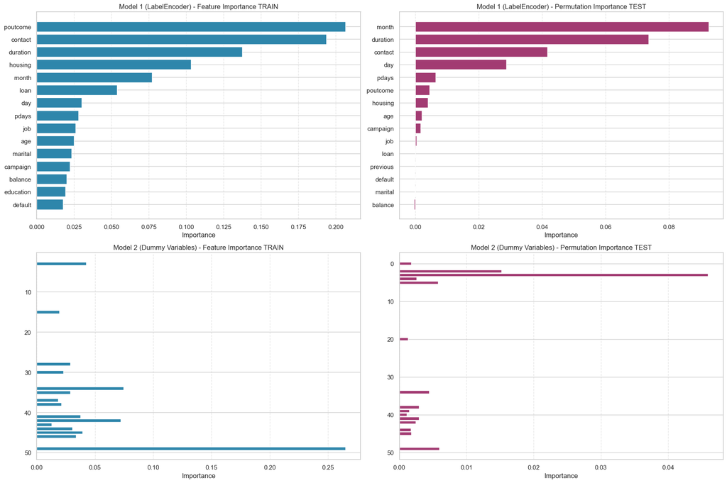

```
Model 1 wykazuje mniej cech o istotnym wpływie ze względu na mniejszą wymiarowość
✓ Model 2 rozprasza ważność na większą liczbę zmiennych dummy reprezentujących kategorie
```

```python
# Feature importance Model 1 (LabelEncoder)
y_pred_train_m1 = model1.predict_proba(X_train_le)[:, 1]
y_pred_test_m1 = model1.predict_proba(X_test_le)[:, 1]
pi_results_m1_train = permutation_importance(model1, X_train_le, y_train, n_repeats=10, random_state=0)
pi_results_m1_test = permutation_importance(model1, X_test_le, y_test, n_repeats=10, random_state=0)

fig, ((ax1, ax2), (ax3, ax4)) = plt.subplots(2, 2, figsize=(18, 12))

# Model 1 - TRAIN
plot_fi_on_ax(ax=ax1, feat_names=X_train_le.columns,
              fi_values=model1.feature_importances_,
              title="Model 1 (LabelEncoder) - Feature Importance TRAIN", color='#2E86AB', top_n=15)

# Model 1 - TEST
plot_fi_on_ax(ax=ax2, feat_names=X_test_le.columns,
              fi_values=pi_results_m1_test.importances_mean,
              title="Model 1 (LabelEncoder) - Permutation Importance TEST", color='#A23B72', top_n=15)

# Model 2 - TRAIN
plot_fi_on_ax(ax=ax3, feat_names=X_train_d.columns,
              fi_values=model2.feature_importances_,
              title="Model 2 (Dummy Variables) - Feature Importance TRAIN", color='#2E86AB', top_n=15)

# Model 2 - TEST
# Obsługa mismatch'u nazw kolumn - konwersja na numpy array aby obejść walidację XGBoost
X_test_array = X_test_d.values
pi_results_m2_test = permutation_importance(model2, X_test_array, y_test, n_repeats=10, random_state=0)
plot_fi_on_ax(ax=ax4, feat_names=X_test_d.columns,
              fi_values=pi_results_m2_test.importances_mean,
              title="Model 2 (Dummy Variables) - Permutation Importance TEST", color='#A23B72', top_n=15)

plt.tight_layout()
plt.show()

print("\nModel 1 wykazuje mniej cech o istotnym wpływie ze względu na mniejszą wymiarowość")
print("✓ Model 2 rozprasza ważność na większą liczbę zmiennych dummy reprezentujących kategorie")
```

```python
model_results
```

|  | Model_Name | Description | Num_Variables | Gini_Train [%] | Gini_Valid [%] | Gini_Test [%] |
| --- | --- | --- | --- | --- | --- | --- |
| 0 | Model 1 | Model na domyślnych hiperparametrach (LabelEnc... | 16 | 98.75 | 84.36 | 85.30 |
| 1 | Model 2 | Model na domyślnych hiperparametrach ze zmienn... | 51 | 97.61 | 84.60 | 86.55 |

```python
model3 = xgb.XGBClassifier()

param_space = {
    'n_estimators':Integer(50,200),
    'max_depth':Integer(3,10),
    'min_child_weight':Integer(1,200),
    'learning_rate':Real(0.01,0.3,prior='log-uniform'),
    'subsample':Real(0.6,1.0),
    'colsample_bytree':Real(0.6,1.0),
    'gamma':Real(1e-4,5,prior='log-uniform'),
    'reg_lambda':Real(1e-4,10,prior='log-uniform'),
    'reg_alpha':Real(1e-4,10,prior='log-uniform')

}
```

### 4.5 Optymalizacja hiperparametrów za pomocą Bayesian Search (Model 3)

Optymalizacja hiperparametrów modelu na zbiorze TRAIN z kodowaniem LabelEncoder:

- **Parametry optymalizowane**:
  - `n_estimators`: liczba drzew decyzyjnych (50-200)
  - `max_depth`: maksymalna głębokość drzewa (3-10)
  - `min_child_weight`: minimalna waga dziecka (1-200)
  - `learning_rate`: szybkość uczenia (0,01-0,3)
  - `subsample`: udział próbek do trenowania (0,6-1,0)
  - `colsample_bytree`: udział cech (0,6-1,0)
  - `gamma`: parametr regularyzacji (1e-4 do 5)
  - `reg_lambda` i `reg_alpha`: parametry L2 i L1 regularyzacji
- **Kryterium**: Maksymalizacja wyniku AUC-ROC
- **Cross-validation**: 3-fold CV
- **Liczba iteracji**: 50

```python
grid_search1 = BayesSearchCV(estimator=xgb.XGBClassifier(enable_categorical=True, tree_method='hist'), search_spaces=param_space, scoring='roc_auc', n_iter=50, cv=3, random_state=42)
grid_search1.fit(X_train_le, y_train)
best_params_1 = grid_search1.best_params_

model_results = pd.concat([model_results, model_summary(
    model=grid_search1.best_estimator_, name='Model 3', description='Model zoptymalizowany (LabelEncoder)',
    xtrain=X_train_le, xtest=X_test_le, xvalid=X_valid_le, ytrain=y_train, ytest=y_test, yvalid=y_valid
)], ignore_index=True)
```

```python
model_results
```

|  | Model_Name | Description | Num_Variables | Gini_Train [%] | Gini_Valid [%] | Gini_Test [%] |
| --- | --- | --- | --- | --- | --- | --- |
| 0 | Model 1 | Model na domyślnych hiperparametrach (LabelEnc... | 16 | 98.75 | 84.36 | 85.30 |
| 1 | Model 2 | Model na domyślnych hiperparametrach ze zmienn... | 51 | 97.61 | 84.60 | 86.55 |
| 2 | Model 3 | Model zoptymalizowany (LabelEncoder) | 16 | 97.16 | 86.23 | 87.44 |

```python
model4 = xgb.XGBClassifier(enable_categorical=True, tree_method='hist', **best_params_1)
model4.fit(X_train_d, y_train)

model_results = pd.concat([model_results, model_summary(
    model=model4, name='Model 4', description='Hiperparametry z M3 na zmiennych dummy',
    xtrain=X_train_d, xtest=X_test_d, xvalid=X_valid_d, ytrain=y_train, ytest=y_test, yvalid=y_valid
)], ignore_index=True)
```

### 4.6 Model 4: Zoptymalizowane hiperparametry na zmiennych dummy

Zastosowanie zoptymalizowanych hiperparametrów (z Model 3) na danych z kodowaniem dummy variables:

```python
model_results
```

|  | Model_Name | Description | Num_Variables | Gini_Train [%] | Gini_Valid [%] | Gini_Test [%] |
| --- | --- | --- | --- | --- | --- | --- |
| 0 | Model 1 | Model na domyślnych hiperparametrach (LabelEnc... | 16 | 98.75 | 84.36 | 85.30 |
| 1 | Model 2 | Model na domyślnych hiperparametrach ze zmienn... | 51 | 97.61 | 84.60 | 86.55 |
| 2 | Model 3 | Model zoptymalizowany (LabelEncoder) | 16 | 97.16 | 86.23 | 87.44 |
| 3 | Model 4 | Hiperparametry z M3 na zmiennych dummy | 51 | 95.76 | 85.57 | 87.07 |

### 4.7 Model 5: Optymalizacja hiperparametrów na zmiennych dummy

Niezależna optymalizacja Bayesian Search na danych z kodowaniem dummy variables:

```python
grid_search2 = BayesSearchCV(estimator=xgb.XGBClassifier(enable_categorical=True, tree_method='hist'), search_spaces=param_space, scoring='roc_auc', n_iter=50, cv=3, random_state=42)
grid_search2.fit(X_train_d, y_train)

model_results = pd.concat([model_results, model_summary(
    model=grid_search2.best_estimator_, name='Model 5', description='Optymalizacja na zmiennych dummy',
    xtrain=X_train_d, xtest=X_test_d, xvalid=X_valid_d, ytrain=y_train, ytest=y_test, yvalid=y_valid
)], ignore_index=True)
```

```python
model_results
```

|  | Model_Name | Description | Num_Variables | Gini_Train [%] | Gini_Valid [%] | Gini_Test [%] |
| --- | --- | --- | --- | --- | --- | --- |
| 0 | Model 1 | Model na domyślnych hiperparametrach (LabelEnc... | 16 | 98.75 | 84.36 | 85.30 |
| 1 | Model 2 | Model na domyślnych hiperparametrach ze zmienn... | 51 | 97.61 | 84.60 | 86.55 |
| 2 | Model 3 | Model zoptymalizowany (LabelEncoder) | 16 | 97.16 | 86.23 | 87.44 |
| 3 | Model 4 | Hiperparametry z M3 na zmiennych dummy | 51 | 95.76 | 85.57 | 87.07 |
| 4 | Model 5 | Optymalizacja na zmiennych dummy | 51 | 91.77 | 85.74 | 87.52 |

### 4.8 Optymalizacja liczby zmiennych w modelu

Analiza wpływu kolejnych zmiennych (posortowanych wg ważności) na wynik Gini modelu. Celem jest określenie, które zmienne są istotne dla predykcji i czy można je usunąć bez utraty mocy modelu.

**Procedura**:

1. Posortowanie zmiennych wg ważności cech (Feature Importance) (malejąco)
2. Iteracyjne dodawanie zmiennych do modelu
3. Obliczenie wyniku GINI dla każdej kombinacji na zbiorach treningowym i testowym
4. Analiza przyrostu GINI - określenie zmiennych, które można usunąć bez utraty jakości predykcji

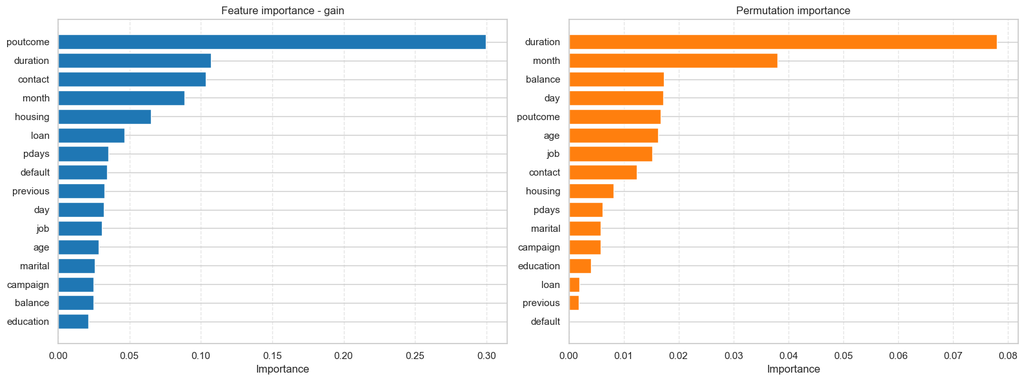

```python
plot_feature_importance(grid_search1.best_estimator_, X_train_le, y_train)
```

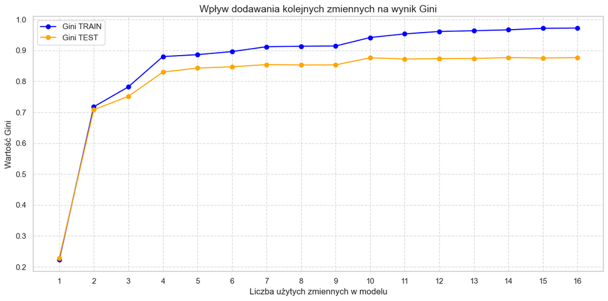

```python
best_model = grid_search1.best_estimator_
fi = best_model.feature_importances_

df_fi = pd.DataFrame({
    'zmienna': X_train_le.columns,
    'waznosc': fi
}).sort_values(by='waznosc', ascending=False)

sorted_features = df_fi['zmienna'].tolist()

gini_train_list = []
gini_test_list = []
n_features_list = list(range(1, len(sorted_features) + 1))

for i in n_features_list:
    selected_columns = sorted_features[:i]
    X_train_sub = X_train_le[selected_columns]
    X_test_sub = X_test_le[selected_columns]


    model_iter = xgb.XGBClassifier(enable_categorical=True, tree_method='hist', **grid_search1.best_params_, random_state=42)

    model_iter.fit(X_train_sub, y_train)

    y_pred_train = model_iter.predict_proba(X_train_sub)[:, 1]
    y_pred_test = model_iter.predict_proba(X_test_sub)[:, 1]

    gini_train = gini(y_train, y_pred_train)
    gini_test = gini(y_test, y_pred_test)
    gini_train_list.append(gini_train)
    gini_test_list.append(gini_test)

plt.figure(figsize=(12, 6))
plt.plot(n_features_list, gini_train_list, label='Gini TRAIN', marker='o', color='blue')
plt.plot(n_features_list, gini_test_list, label='Gini TEST', marker='o', color='orange')

plt.title('Wpływ dodawania kolejnych zmiennych na wynik Gini', fontsize=14)
plt.xlabel('Liczba użytych zmiennych w modelu', fontsize=12)
plt.ylabel('Wartość Gini', fontsize=12)
plt.xticks(n_features_list)
plt.legend()
plt.grid(True, linestyle='--', alpha=0.7)
plt.tight_layout()
plt.show()
```

**Analiza przyrostu GINI - tabela wyników:**

```python
df_gini_table = pd.DataFrame({
    'Liczba_zmiennych': n_features_list,
    'Gini_Train [%]': [round(x * 100, 2) for x in gini_train_list],
    'Gini_Test [%]': [round(x * 100, 2) for x in gini_test_list]
})

df_gini_table
```

|  | Liczba_zmiennych | Gini_Train [%] | Gini_Test [%] |
| --- | --- | --- | --- |
| 0 | 1 | 22.24 | 22.83 |
| 1 | 2 | 71.77 | 70.82 |
| 2 | 3 | 78.21 | 75.13 |
| 3 | 4 | 88.01 | 83.00 |
| 4 | 5 | 88.63 | 84.29 |
| 5 | 6 | 89.63 | 84.71 |
| 6 | 7 | 91.20 | 85.42 |
| 7 | 8 | 91.35 | 85.28 |
| 8 | 9 | 91.43 | 85.32 |
| 9 | 10 | 94.18 | 87.62 |
| 10 | 11 | 95.35 | 87.21 |
| 11 | 12 | 96.13 | 87.34 |
| 12 | 13 | 96.38 | 87.39 |
| 13 | 14 | 96.66 | 87.68 |
| 14 | 15 | 97.15 | 87.55 |
| 15 | 16 | 97.22 | 87.66 |

### 4.10 Optymalizacja doboru cech - wizualizacja

Wizualizacja wyników GINI dla różnych liczb zmiennych. Ten wykres pomaga zidentyfikować optymalną liczbę cech, przy której wynik na zbiorze testowym stabilizuje się i gdzie można obserwować symptomy przeuczenia (luka między zbiorem treningowym a testowym).

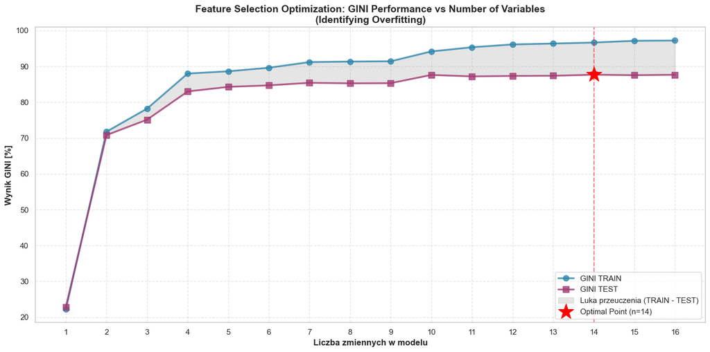

```
======================================================================
ANALIZA DOBORU CECH - KLUCZOWE WNIOSKI
======================================================================
Optymalna liczba zmiennych: 14
GINI testowy przy optimum: 87.68%
GINI treningowy przy optimum: 96.66%
Luka przeuczenia: 8.98%
======================================================================
```

```python
fig, ax = plt.subplots(figsize=(14, 7))


ax.plot(df_gini_table['Liczba_zmiennych'], df_gini_table['Gini_Train [%]'],
        marker='o', linewidth=2.5, markersize=8, label='GINI TRAIN',
        color='#2E86AB', alpha=0.8)
ax.plot(df_gini_table['Liczba_zmiennych'], df_gini_table['Gini_Test [%]'],
        marker='s', linewidth=2.5, markersize=8, label='GINI TEST',
        color='#A23B72', alpha=0.8)


ax.fill_between(df_gini_table['Liczba_zmiennych'],
                df_gini_table['Gini_Train [%]'],
                df_gini_table['Gini_Test [%]'],
                alpha=0.2, color='gray', label='Luka przeuczenia (TRAIN - TEST)')


optimal_idx = df_gini_table['Gini_Test [%]'].idxmax()
optimal_n_vars = df_gini_table.loc[optimal_idx, 'Liczba_zmiennych']
optimal_gini_test = df_gini_table.loc[optimal_idx, 'Gini_Test [%]']

ax.scatter(optimal_n_vars, optimal_gini_test, marker='*', s=500, color='red',
          zorder=5, label=f'Optimal Point (n={optimal_n_vars})')
ax.axvline(x=optimal_n_vars, color='red', linestyle='--', alpha=0.5)


ax.set_xlabel('Liczba zmiennych w modelu', fontsize=12, fontweight='bold')
ax.set_ylabel('Wynik GINI [%]', fontsize=12, fontweight='bold')
ax.set_title('Feature Selection Optimization: GINI Performance vs Number of Variables\n(Identifying Overfitting)',
            fontsize=14, fontweight='bold')
ax.legend(fontsize=11, loc='lower right')
ax.grid(True, linestyle='--', alpha=0.5)
ax.set_xticks(df_gini_table['Liczba_zmiennych'])

plt.tight_layout()
plt.show()


print("\n" + "="*70)
print("ANALIZA DOBORU CECH - KLUCZOWE WNIOSKI")
print("="*70)
print(f"Optymalna liczba zmiennych: {int(optimal_n_vars)}")
print(f"GINI testowy przy optimum: {optimal_gini_test:.2f}%")
print(f"GINI treningowy przy optimum: {df_gini_table.loc[optimal_idx, 'Gini_Train [%]']:.2f}%")
print(f"Luka przeuczenia: {df_gini_table.loc[optimal_idx, 'Gini_Train [%]'] - optimal_gini_test:.2f}%")
print("="*70)
```